# Intro to data wrangling

April 20, 2018

## Normal data manipulation in R

```r
# Changes spp to factor
plants$Species <- as.factor(plants$Species)
# Changes plant code to factor
plants$Plant.Code <- as.factor(plants$Plant.Code)
# Changes Seed to factor
seeds$Seed <- as.factor(seeds$Seed)
# Changes plant code to factor
seeds$Plant.Code <- as.factor(seeds$Plant.Code)
# Selects Flower, Code, Total.Germ columns
germ <- germ[, c("Flower", "Code", "Total.Germ")]

# Sets numerics
plants[, c(3:9)] <- as.numeric(unlist(plants[, c(3:9)]))
# Sets Dates
seeds$Collection.Date <- as.Date(seeds$Collection.Date, origin = "2012-01-01")
```

## Data manipulation using dplyr/tidyr

```r
library(dplyr)
library(tidyr)
# Convert factors in plants df
plants <- mutate(plants, Species = factor(Species), Plant.Code = factor(Plant.Code))
# Convert factors in seeds df
seeds <- mutate(seeds, Seed = factor(Seed), Plant.Code = factor(Plant.Code))
# Select Flower, Code, and Total.Germ columns in germ df
germ <- select(germ, Flower, Code, Total.Germ)

# Change columns 3:9 to numeric
plants <- plants %>% mutate_at(vars(3:9), funs(as.numeric))
# Convert Collection.Date to Date format
seeds <- mutate(Collection.Date = as.Date(Collection.Date, origin = "2012-01-01"))
```

- More compact, less typing
- Easier to read
- Faster (matters for large datasets)

## How does this work?

Things to learn today:

- Basic syntax and table verbs
- Piping
- Reshaping
- Grouping
- Exercise!
- Final remarks

## Basic Syntax

Both dplyr and tidyr work with data frames or tibbles

- data frame: similar to matrix, but with different data types for each column
- tibble: "compact" data frame, with some annoying features removed

```r
head(iris)  #Regular data frame
```

```
##   Sepal.Length Sepal.Width Petal.Length Petal.Width Species
## 1          5.1         3.5          1.4         0.2  setosa
## 2          4.9         3.0          1.4         0.2  setosa
## 3          4.7         3.2          1.3         0.2  setosa
## 4          4.6         3.1          1.5         0.2  setosa
## 5          5.0         3.6          1.4         0.2  setosa
## 6          5.4         3.9          1.7         0.4  setosa
```

## Basic Syntax

```r
as_tibble(iris)  #This is usually done automatically
```

```
## # A tibble: 150 x 5
##    Sepal.Length Sepal.Width Petal.Length Petal.Width Species
##           <dbl>       <dbl>        <dbl>       <dbl> <fct>
##  1         5.10        3.50         1.40       0.200 setosa
##  2         4.90        3.00         1.40       0.200 setosa
##  3         4.70        3.20         1.30       0.200 setosa
##  4         4.60        3.10         1.50       0.200 setosa
##  5         5.00        3.60         1.40       0.200 setosa
##  6         5.40        3.90         1.70       0.400 setosa
##  7         4.60        3.40         1.40       0.300 setosa
##  8         5.00        3.40         1.50       0.200 setosa
##  9         4.40        2.90         1.40       0.200 setosa
## 10         4.90        3.10         1.50       0.100 setosa
## # ... with 140 more rows
```

## Basic verbs - subsetting

- **select**: returns only columns that you want

```r
head(iris, 3)
```

```
##   Sepal.Length Sepal.Width Petal.Length Petal.Width Species
## 1          5.1         3.5          1.4         0.2  setosa
## 2          4.9         3.0          1.4         0.2  setosa
## 3          4.7         3.2          1.3         0.2  setosa
```

```r
# Select Petal.Length,Petal.Width,Species
irisTemp <- select(iris, Petal.Length, Petal.Width, Species)
head(irisTemp, 3)
```

```
##   Petal.Length Petal.Width Species
## 1          1.4         0.2  setosa
## 2          1.4         0.2  setosa
## 3          1.3         0.2  setosa
```

## Basic verbs - subsetting

Helper functions for **select**: *colon* operator

```r
irisTemp <- select(iris, Petal.Length:Species)
head(irisTemp, 3)  #All columns between Petal.Length and Species
```

```
##   Petal.Length Petal.Width Species
## 1          1.4         0.2  setosa
## 2          1.4         0.2  setosa
## 3          1.3         0.2  setosa
```

```r
irisTemp2 <- select(iris, Petal.Length, Petal.Width, Species)
head(irisTemp2, 3)  #This is the same thing
```

```
##   Petal.Length Petal.Width Species
## 1          1.4         0.2  setosa
## 2          1.4         0.2  setosa
## 3          1.3         0.2  setosa
```

## Basic verbs - subsetting

Helper functions for **select**: -, and *contains*

```r
irisTemp <- select(iris, -Species)
head(irisTemp, 3)  #Selects all columns EXCEPT Species
```

```
##   Sepal.Length Sepal.Width Petal.Length Petal.Width
## 1          5.1         3.5          1.4         0.2
## 2          4.9         3.0          1.4         0.2
## 3          4.7         3.2          1.3         0.2
```

```r
irisTemp2 <- select(iris, contains("Petal"))
head(irisTemp2, 3)  #Selects columns with names containing 'Petal'
```

```
##   Petal.Length Petal.Width
## 1          1.4         0.2
## 2          1.4         0.2
## 3          1.3         0.2
```

## Basic verbs - subsetting

- **filter**: returns only rows that you want

```r
head(iris, 3)
```

```
##   Sepal.Length Sepal.Width Petal.Length Petal.Width Species
## 1          5.1         3.5          1.4         0.2  setosa
## 2          4.9         3.0          1.4         0.2  setosa
## 3          4.7         3.2          1.3         0.2  setosa
```

```r
irisTemp <- filter(iris, Sepal.Length < 5, Species == "versicolor")
head(irisTemp, 3)  #Chooses rows matching logical criteria
```

```
##   Sepal.Length Sepal.Width Petal.Length Petal.Width    Species
## 1          4.9         2.4          3.3           1 versicolor
```

## Basic verbs - make new variables

- **mutate**: add variables or alter existing ones

```r
head(iris, 3)
```

```
##   Sepal.Length Sepal.Width Petal.Length Petal.Width Species
## 1          5.1         3.5          1.4         0.2  setosa
## 2          4.9         3.0          1.4         0.2  setosa
## 3          4.7         3.2          1.3         0.2  setosa
```

```r
irisTemp <- mutate(iris, P.Width2 = Petal.Width^2)
head(irisTemp, 3)  #Squares Petal.Width
```

```
##   Sepal.Length Sepal.Width Petal.Length Petal.Width Species P.Width2
## 1          5.1         3.5          1.4         0.2  setosa     0.04
## 2          4.9         3.0          1.4         0.2  setosa     0.04
## 3          4.7         3.2          1.3         0.2  setosa     0.04
```

## Basic verbs - make new variables

```r
head(irisTemp, 3)
```

```
##   Sepal.Length Sepal.Width Petal.Length Petal.Width Species P.Width2
## 1          5.1         3.5          1.4         0.2  setosa     0.04
## 2          4.9         3.0          1.4         0.2  setosa     0.04
## 3          4.7         3.2          1.3         0.2  setosa     0.04
```

```r
irisTemp <- mutate(iris, P.Width2 = (Petal.Width^2) * 2)
head(irisTemp, 3)  #Alters variable in place
```

```
##   Sepal.Length Sepal.Width Petal.Length Petal.Width Species P.Width2
## 1          5.1         3.5          1.4         0.2  setosa     0.08
## 2          4.9         3.0          1.4         0.2  setosa     0.08
## 3          4.7         3.2          1.3         0.2  setosa     0.08
```

## Basic verbs - make new variables

- **mutate_at**: uses same function on columns of choice

```r
head(iris, 3)
```

```
##   Sepal.Length Sepal.Width Petal.Length Petal.Width Species
## 1          5.1         3.5          1.4         0.2  setosa
## 2          4.9         3.0          1.4         0.2  setosa
## 3          4.7         3.2          1.3         0.2  setosa
```

```r
irisTemp <- mutate_at(iris, vars(Petal.Width, Petal.Length), funs(.^2))
head(irisTemp, 3)  #Squares Petal.Width & Length. '.' means 'data from column'
```

```
##   Sepal.Length Sepal.Width Petal.Length Petal.Width Species
## 1          5.1         3.5         1.96        0.04  setosa
## 2          4.9         3.0         1.96        0.04  setosa
## 3          4.7         3.2         1.69        0.04  setosa
```

## Basic verbs - make new variables

- **rename** & **transmute**

```r
irisTemp <- rename(iris, PWidth = Petal.Width, PLength = Petal.Length)
head(irisTemp, 3)  #Renames columns
```

```
##   Sepal.Length Sepal.Width PLength PWidth Species
## 1          5.1         3.5     1.4    0.2  setosa
## 2          4.9         3.0     1.4    0.2  setosa
## 3          4.7         3.2     1.3    0.2  setosa
```

```r
irisTemp2 <- transmute(iris, P.Width2 = (Petal.Width^2))
head(irisTemp2, 3)  #Same as mutate, but drops other columns
```

```
##   P.Width2
## 1     0.04
## 2     0.04
## 3     0.04
```

## Exercises!

Using the *iris* dataset:

- Filter only "virginica" rows
- Make 2 new "area" columns, which are length \(\times\) width of Petals and Sepals
- Get rid of all columns except "Species" + 2 new columns

```
##      Species P.Area S.Area
## 1  virginica  15.00  20.79
## 2  virginica   9.69  15.66
## 3  virginica  12.39  21.30
## 4  virginica  10.08  18.27
## 5  virginica  12.76  19.50
## 6  virginica  13.86  22.80
## 7  virginica   7.65  12.25
## 8  virginica  11.34  21.17
## 9  virginica  10.44  16.75
## 10 virginica  15.25  25.92
```

## Piping - %>%

- Takes data from one verb and passes it to the next one
- Allows you to string together complex operations

```r
irisTemp <- select(iris,Sepal.Length,Species) %>% #Selects Sepal.Length & Species
  filter(Sepal.Length>5,Species=='versicolor') %>% #Filters using dataframe from above
  mutate(SLength2=Sepal.Length^2) #Mutates using dataframe from above
head(irisTemp)
```

```
##   Sepal.Length    Species SLength2
## 1          7.0 versicolor    49.00
## 2          6.4 versicolor    40.96
## 3          6.9 versicolor    47.61
## 4          5.5 versicolor    30.25
## 5          6.5 versicolor    42.25
## 6          5.7 versicolor    32.49
```

## Reshaping

- This is very tedious to do in base R and Excel
- Reshaping operations in tidyr make this much easier
- Four main commands:
1. **gather** - gather columns into rows ('long format')
2. **spread** - spread rows into columns ('wide format')
3. **unite** - unite many columns into one (similar to *paste*)
4. **separate** - separates one column into many (similar to *strsplit*)

## Reshaping - *gather*: columns to rows

- Make some data in "wide" format

```r
#Some fake data to work with
(fake <- data.frame(time = as.Date('2009-01-01') + 0:4,
                      X = rnorm(5, 0, 1),Y = rnorm(5, 0, 2)))
```

```
##         time             X          Y
## 1 2009-01-01 -0.2990921006  1.0675986
## 2 2009-01-02 -1.0358757365 -0.7773559
## 3 2009-01-03  1.1283030754 -0.4582967
## 4 2009-01-04 -1.1025806215 -0.2565181
## 5 2009-01-05  0.0006298519  1.3281489
```

## Reshaping - *gather*: columns to rows

- Change "wide" dataframe to "long" dataframe

```r
(fakeLong <- gather(fake, type, measurement, -time))
```

```
##          time type   measurement
## 1  2009-01-01    X -0.2990921006
## 2  2009-01-02    X -1.0358757365
## 3  2009-01-03    X  1.1283030754
## 4  2009-01-04    X -1.1025806215
## 5  2009-01-05    X  0.0006298519
## 6  2009-01-01    Y  1.0675985860
## 7  2009-01-02    Y -0.7773559434
## 8  2009-01-03    Y -0.4582967281
## 9  2009-01-04    Y -0.2565181138
## 10 2009-01-05    Y  1.3281488806
```

## Reshaping - *spread*: rows to columns

```r
fakeLong <- gather(fake,type, measurement, -time)
fakeLong %>% spread(type, measurement)
```

```
##         time             X          Y
## 1 2009-01-01 -0.2990921006  1.0675986
## 2 2009-01-02 -1.0358757365 -0.7773559
## 3 2009-01-03  1.1283030754 -0.4582967
## 4 2009-01-04 -1.1025806215 -0.2565181
## 5 2009-01-05  0.0006298519  1.3281489
```

```r
fakeLong %>% spread(time, measurement) #What has this done?
```

```
##   type 2009-01-01 2009-01-02 2009-01-03 2009-01-04   2009-01-05
## 1    X -0.2990921 -1.0358757  1.1283031 -1.1025806 0.0006298519
## 2    Y  1.0675986 -0.7773559 -0.4582967 -0.2565181 1.3281488806
```

```r
#Note: this must have unique row identifiers
```

## Reshaping - *unite*: many columns into one

- Useful when combined with other reshaping functions

```r
irisTemp <- iris %>% unite(newCol,Sepal.Length:Petal.Width,sep='_')
head(irisTemp,10)
```

```
##             newCol Species
## 1  5.1_3.5_1.4_0.2  setosa
## 2    4.9_3_1.4_0.2  setosa
## 3  4.7_3.2_1.3_0.2  setosa
## 4  4.6_3.1_1.5_0.2  setosa
## 5    5_3.6_1.4_0.2  setosa
## 6  5.4_3.9_1.7_0.4  setosa
## 7  4.6_3.4_1.4_0.3  setosa
## 8    5_3.4_1.5_0.2  setosa
## 9  4.4_2.9_1.4_0.2  setosa
## 10 4.9_3.1_1.5_0.1  setosa
```

## Reshaping - *separate*: one column into many

```r
irisTemp %>% separate(newCol,c('SLength','SWidth','PLength','PWidth'),sep='_')
```

```
##     SLength SWidth PLength PWidth    Species
## 1       5.1    3.5     1.4    0.2     setosa
## 2       4.9      3     1.4    0.2     setosa
## 3       4.7    3.2     1.3    0.2     setosa
## 4       4.6    3.1     1.5    0.2     setosa
## 5         5    3.6     1.4    0.2     setosa
## 6       5.4    3.9     1.7    0.4     setosa
## 7       4.6    3.4     1.4    0.3     setosa
## 8         5    3.4     1.5    0.2     setosa
## 9       4.4    2.9     1.4    0.2     setosa
## 10      4.9    3.1     1.5    0.1     setosa
## 11      5.4    3.7     1.5    0.2     setosa
## 12      4.8    3.4     1.6    0.2     setosa
## 13      4.8      3     1.4    0.1     setosa
## 14      4.3      3     1.1    0.1     setosa
```

[output cut: 136 more lines]

## Reshaping - combinations of reshaping functions

Say we wanted lengths and widths in separate columns, split by Petal & Sepal

```r
irisTemp <- iris %>% unite(sepals,Sepal.Length:Sepal.Width,sep='_') %>%
  unite(petals,Petal.Length:Petal.Width,sep='_')
  head(irisTemp,10)
```

```
##     sepals  petals Species
## 1  5.1_3.5 1.4_0.2  setosa
## 2    4.9_3 1.4_0.2  setosa
## 3  4.7_3.2 1.3_0.2  setosa
## 4  4.6_3.1 1.5_0.2  setosa
## 5    5_3.6 1.4_0.2  setosa
## 6  5.4_3.9 1.7_0.4  setosa
## 7  4.6_3.4 1.4_0.3  setosa
## 8    5_3.4 1.5_0.2  setosa
## 9  4.4_2.9 1.4_0.2  setosa
## 10 4.9_3.1 1.5_0.1  setosa
```

## Reshaping - combinations of reshaping functions

- Now that measurements are *united*, we *gather* and then *separate* them

```r
irisTemp %>% gather('Type','Measurement',sepals:petals) %>%
  separate(Measurement,c('Length','Width'),sep='_',convert=T) %>%
  head(10)
```

```
##    Species   Type Length Width
## 1   setosa sepals    5.1   3.5
## 2   setosa sepals    4.9   3.0
## 3   setosa sepals    4.7   3.2
## 4   setosa sepals    4.6   3.1
## 5   setosa sepals    5.0   3.6
## 6   setosa sepals    5.4   3.9
## 7   setosa sepals    4.6   3.4
## 8   setosa sepals    5.0   3.4
## 9   setosa sepals    4.4   2.9
## 10  setosa sepals    4.9   3.1
```

## Exercises!

Using the *CO2* dataset:

- Select only *non-chilled* plants from *Quebec*
- Pipe data frame to next command
- Change the uptake dataset from long to wide format (each plant should have its own column), with a column at the beginning showing concentration
- Hint: *filter* rows and *select* columns you need, then *spread* to wide format

```
##   conc  Qn1  Qn2  Qn3
## 1   95 16.0 13.6 16.2
## 2  175 30.4 27.3 32.4
## 3  250 34.8 37.1 40.3
## 4  350 37.2 41.8 42.1
## 5  500 35.3 40.6 42.9
## 6  675 39.2 41.4 43.9
## 7 1000 39.7 44.3 45.5
```

## Grouping

- Often, we want to perform operations only on groups within data frames
- For example, what is the average of each species' *Petal.width*?

```r
with(iris,tapply(Petal.Width,Species,mean))
```

```
##     setosa versicolor  virginica
##      0.246      1.326      2.026
```

```r
aggregate(Petal.Width~Species,data=iris,mean)
```

```
##      Species Petal.Width
## 1     setosa       0.246
## 2 versicolor       1.326
## 3  virginica       2.026
```

## Grouping

- How can this be done in dplyr/tidyr?

```r
iris %>% group_by(Species) %>%
  summarize(meanPWidth=mean(Petal.Width),sdPWidth=sd(Petal.Width))
```

```
## # A tibble: 3 x 3
##   Species    meanPWidth sdPWidth
##   <fct>           <dbl>    <dbl>
## 1 setosa          0.246    0.105
## 2 versicolor      1.33     0.198
## 3 virginica       2.03     0.275
```

- Apply *grouping*, then use *summary function*
- Data frame can be fed into other functions after summarizing

## Grouping - Examples

```r
iris %>% group_by(Species) %>%
  summarize(count=n(),med=median(Petal.Width),iqr=IQR(Petal.Width))
```

```
## # A tibble: 3 x 4
##   Species    count   med   iqr
##   <fct>      <int> <dbl> <dbl>
## 1 setosa        50 0.200 0.100
## 2 versicolor    50 1.30  0.300
## 3 virginica     50 2.00  0.500
```

- *n* is empty, because it uses the length of the subsetted data frame

## Grouping - Examples

- Also useful for applying functions to subsets of data, *without* summarizing

```r
iris %>% group_by(Species) %>% mutate(ID=1:n()) %>% #Makes ID column, with numbers 1-N
  filter(ID<4) #Selects ID 1-3 from each group
```

```
## # A tibble: 9 x 6
## # Groups:   Species [3]
##   Sepal.Length Sepal.Width Petal.Length Petal.Width Species       ID
##          <dbl>       <dbl>        <dbl>       <dbl> <fct>      <int>
## 1         5.10        3.50         1.40       0.200 setosa         1
## 2         4.90        3.00         1.40       0.200 setosa         2
## 3         4.70        3.20         1.30       0.200 setosa         3
## 4         7.00        3.20         4.70       1.40  versicolor     1
## 5         6.40        3.20         4.50       1.50  versicolor     2
## 6         6.90        3.10         4.90       1.50  versicolor     3
## 7         6.30        3.30         6.00       2.50  virginica      1
## 8         5.80        2.70         5.10       1.90  virginica      2
## 9         7.10        3.00         5.90       2.10  virginica      3
```

## Grouping

- Another way of doing the same thing

```r
iris %>% group_by(Species) %>%
  slice(1:3) #Selects rows 1-3 from each group
```

```
## # A tibble: 9 x 5
## # Groups:   Species [3]
##   Sepal.Length Sepal.Width Petal.Length Petal.Width Species
##          <dbl>       <dbl>        <dbl>       <dbl> <fct>
## 1         5.10        3.50         1.40       0.200 setosa
## 2         4.90        3.00         1.40       0.200 setosa
## 3         4.70        3.20         1.30       0.200 setosa
## 4         7.00        3.20         4.70       1.40  versicolor
## 5         6.40        3.20         4.50       1.50  versicolor
## 6         6.90        3.10         4.90       1.50  versicolor
## 7         6.30        3.30         6.00       2.50  virginica
## 8         5.80        2.70         5.10       1.90  virginica
## 9         7.10        3.00         5.90       2.10  virginica
```

- You can use most of the subset and window functions across groups

## Exercises!

Using the *InsectSprays* dataset:

- Find the mean and SD of each type of spray type
- Reshape dataframe so that each spray has its own column, with mean and SD in separate rows
- Hint: get summary stats first, then *gather* and *spread*

```
## # A tibble: 2 x 7
##   stat      A     B     C     D     E     F
##   <chr> <dbl> <dbl> <dbl> <dbl> <dbl> <dbl>
## 1 mean  14.5  15.3   2.08  4.92  3.50 16.7
## 2 sd     4.72  4.27  1.98  2.50  1.73  6.21
```

## Final remarks

- dplyr & tidyr interface well with other parts of the tidyverse

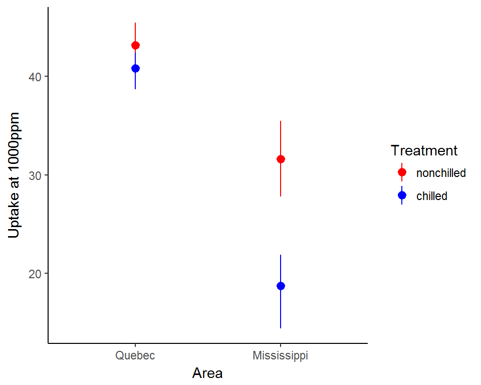

```r
library(ggplot2)
CO2 %>% filter(conc==1000) %>%
  group_by(Type,Treatment) %>%
  summarize(meanUp=mean(uptake),
            maxUp=max(uptake),
            minUp=min(uptake)) %>%
  #Code for ggplot begins here
  ggplot(aes(x=Type,col=Treatment))+
  geom_pointrange(aes(y=meanUp,ymax=maxUp,ymin=minUp))+
  labs(x='Area',y='Uptake at 1000ppm')+
  scale_colour_manual(values=c('red','blue'))
```

## Final remarks

- dplyr & tidyr can pass data frames to and from other functions: use '.' operator

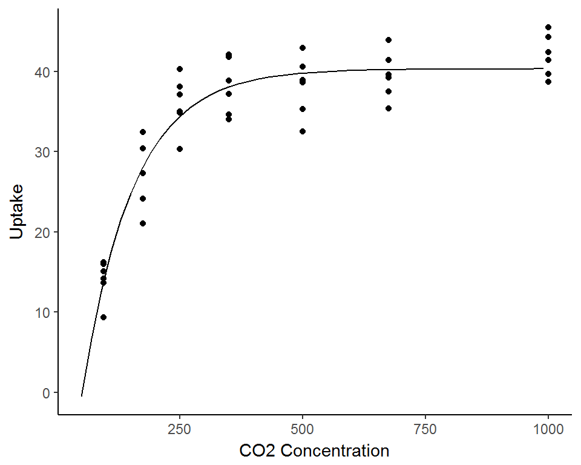

```r
co2mod <- CO2 %>%
  filter(Type=='Quebec') %>% data.frame() %>%
  #Code for nls begins here
  nls(uptake~SSasymp(conc,A,B,C),
      start=list(A=40,B=-25,C=-5),data=.)

data.frame(conc=seq(50,1000,20)) %>%
  predict(co2mod,newdata=.) %>%
  data.frame(conc=seq(50,1000,20),predUp=.) %>%
  #Code for ggplot begins here
  ggplot(aes(conc,predUp))+
  geom_line()+
  geom_point(data=filter(CO2,Type=='Quebec'),
             aes(conc,uptake))+
  labs(x='CO2 Concentration',y='Uptake')
```